# Pricing GLM

## **MODELE DE PRICING AUTO**

Choix sur la méthode :

```python
#%% Import des librairies
import sklearn
import seaborn as sns
import scipy.stats as stats
import numpy as np
import pandas as pd
import matplotlib.pyplot as plt
import statsmodels.api as sm
import statsmodels.formula.api as smf
import warnings
import patsy
```

```python
data_path1 = "../datasets/freMTPL2freq.csv"

data_path2 = "../datasets/freMTPL2sev.csv"

df_freq = pd.read_csv(data_path1)
df_sev = pd.read_csv(data_path2, sep=";")
```

```python
pd.set_option("display.max_rows", 20)
pd.set_option("display.max_columns", 20)
pd.set_option("display.width", 100)
pd.set_option("display.max_colwidth", 50)
```

## **CHOIX DE LA DISTRIBUTION DE LA CIBLE Y (fréquence sinistress)**

Le nombre de sinistres est une variable de comptage. Elle pourrait être modélisée par une distribution binomiale. Cependant, lorsque le nombre d'individus est grand ($n \to +\infty$), et la probabilité sur un évènement d'observer un sinistre tent vers 0, la modélisation se fait par une loi de Poisson. Dans notre dataset, le nombre élevé d'individus et la surreprésentation des 0 justifie la modélisation par une loi de poisson.

Le nombre élevé de 0 peut entraîner une surdispersion $(E(Y\mid X)<V(E(Y\mid X)))$ ce qui ne respecte pas les hypothèses de la loi de poisson $E(Y \mid X) = V(Y \mid X) = \lambda$. Dans ce cas la loi binomiale négative lui sera préféré

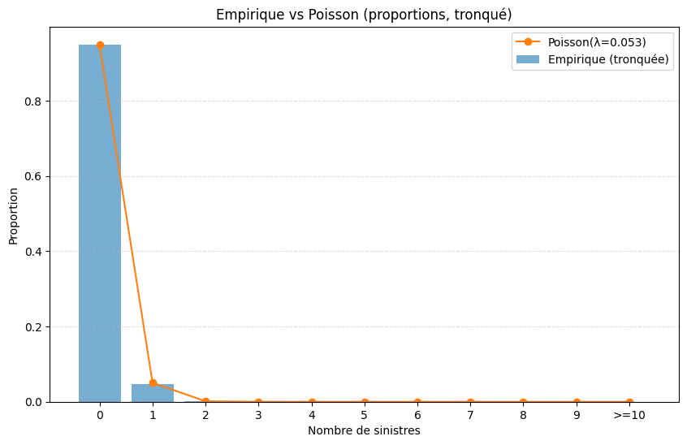

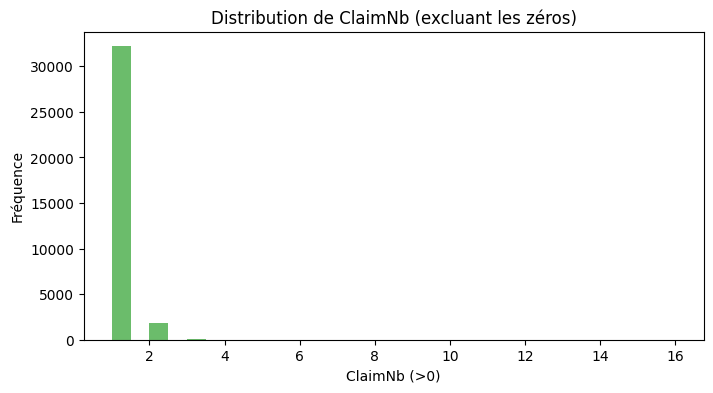

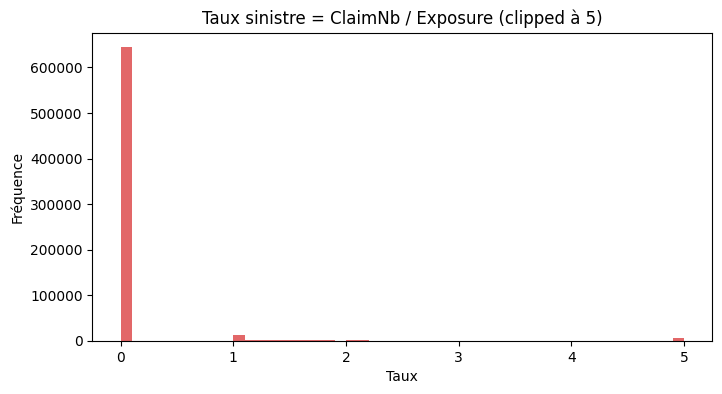

```python
from scipy.stats import poisson, nbinom
# Comptages bruts
counts = df_freq['ClaimNb'].value_counts().sort_index()

# 1) Troncature et agrégation de la queue
max_k = 10
counts_trunc = counts.reindex(range(0, max_k), fill_value=0)
tail = counts[counts.index >= max_k].sum()
counts_trunc[max_k] = tail  # catégorie ">= max_k"
labels = list(range(0, max_k)) + [f">={max_k}"]

# positions numériques
x = np.arange(len(labels))

# estimateur lambda
lambda_hat = df_freq['ClaimNb'].mean()

# pmf Poisson avec masse de la queue
pmf = poisson.pmf(np.arange(0, max_k), lambda_hat)
p_tail = 1 - poisson.cdf(max_k - 1, lambda_hat)
pmf_with_tail = np.append(pmf, p_tail)


obs_prop = counts_trunc.values / counts_trunc.values.sum()
plt.figure(figsize=(10,6))
plt.bar(x, obs_prop, color='C0', alpha=0.6, label='Empirique (tronquée)')
plt.plot(x, pmf_with_tail, 'o-', color='C1', label=f'Poisson(λ={lambda_hat:.3f})')
plt.xticks(x, labels)
plt.title('Empirique vs Poisson (proportions, tronqué)')
plt.xlabel('Nombre de sinistres')
plt.ylabel('Proportion')
plt.legend()
plt.grid(axis='y', linestyle='--', alpha=0.4)
plt.show()

# 3) Zoom : histogramme sans les zéros
plt.figure(figsize=(8,4))
plt.hist(df_freq.loc[df_freq['ClaimNb']>0, 'ClaimNb'], bins=30, color='C2', alpha=0.7)
plt.title('Distribution de ClaimNb (excluant les zéros)')
plt.xlabel('ClaimNb (>0)')
plt.ylabel('Fréquence')
plt.show()

# 4) Visualiser le taux ClaimNb / Exposure (fortement recommandé si Exposure varie)
if 'Exposure' in df_freq.columns:
    rate = df_freq['ClaimNb'] / df_freq['Exposure']
    plt.figure(figsize=(8,4))
    plt.hist(rate.clip(upper=5), bins=50, color='C3', alpha=0.7)  # clip pour éviter longues queues
    plt.title('Taux sinistre = ClaimNb / Exposure (clipped à 5)')
    plt.xlabel('Taux')
    plt.ylabel('Fréquence')
    plt.show()
```

On va faire une première régression de poisson sur les données d'abord sans sélectionner de variables.

La fonction de lien est la fonction $\log$ et $\eta\ = \beta'*X$ le prédicteur linéaire

On aura $E(Y \mid X) = \lambda = exp(\eta)$

avec l'offset $\phi$ : $E(Y \mid X) = \lambda = exp(\eta + \log(\phi))$

```python
# liste des colonnes de df_freq
feature_cols = [col for col in df_freq.columns]
display(feature_cols)
```

```
['IDpol',
 'ClaimNb',
 'Exposure',
 'VehPower',
 'VehAge',
 'DrivAge',
 'BonusMalus',
 'VehBrand',
 'VehGas',
 'Area',
 'Density',
 'Region']
```

L'âge du conducteur et l'âge du véhicule bien que continues, ont un effet non-linéaire sur la fréquence de sinistres. Afin de prendre en compte ces effets, des formules polynomiales par morceaux (splines) sont utilisées ici pour ces variables dans la formule du prédicteur linéaire.

```python
from patsy import bs  # pour splines
dfm = df_freq.loc[df_freq["Exposure"] > 0].copy()

# Formule : caté en C(), numériques en continu (splines conseillées)
formula = (
    "ClaimNb ~ "
    "C(VehBrand) + C(VehGas) + C(Area) + C(Region) + "
    "bs(DrivAge, df=5) + bs(VehAge, df=5) + "
    "BonusMalus + VehPower + Density"
)

modelPoisson = smf.glm(
    formula=formula,
    data=dfm,
    family=sm.families.Poisson(),
    exposure=dfm["Exposure"],
)

resPoisson = modelPoisson.fit()       # robuste
print(resPoisson.summary2())
```

```
                            Results: Generalized linear model
=========================================================================================
Model:                       GLM                     AIC:                   282778.0943
Link Function:               Log                     BIC:                   -8889601.0763
Dependent Variable:          ClaimNb                 Log-Likelihood:        -1.4134e+05
Date:                        2025-12-26 20:51        LL-Null:               -1.4690e+05
No. Observations:            678013                  Deviance:              2.1336e+05
Df Model:                    49                      Pearson chi2:          1.59e+06
Df Residuals:                677963                  Scale:                 1.0000
Method:                      IRLS
-----------------------------------------------------------------------------------------
                                          Coef.  Std.Err.    z     P>|z|   [0.025  0.975]
-----------------------------------------------------------------------------------------
Intercept                                -2.4264   0.1071 -22.6627 0.0000 -2.6362 -2.2165
C(VehBrand)[T.B10]                       -0.0053   0.0368  -0.1442 0.8853 -0.0775  0.0669
C(VehBrand)[T.B11]                        0.0655   0.0396   1.6542 0.0981 -0.0121  0.1432
C(VehBrand)[T.B12]                        0.1123   0.0181   6.2063 0.0000  0.0768  0.1477
C(VehBrand)[T.B13]                        0.0281   0.0409   0.6872 0.4920 -0.0521  0.1084
C(VehBrand)[T.B14]                       -0.1807   0.0784  -2.3034 0.0213 -0.3345 -0.0269
C(VehBrand)[T.B2]                        -0.0138   0.0153  -0.9018 0.3672 -0.0437  0.0162
C(VehBrand)[T.B3]                         0.0070   0.0219   0.3195 0.7493 -0.0359  0.0499
C(VehBrand)[T.B4]                        -0.0309   0.0298  -1.0390 0.2988 -0.0892  0.0274
C(VehBrand)[T.B5]                         0.0638   0.0248   2.5740 0.0101  0.0152  0.1123
C(VehBrand)[T.B6]                        -0.0459   0.0284  -1.6181 0.1057 -0.1016  0.0097
C(VehGas)[T.Regular]                      0.0615   0.0110   5.5930 0.0000  0.0399  0.0831
C(Area)[T.B]                              0.0545   0.0217   2.5071 0.0122  0.0119  0.0971
C(Area)[T.C]                              0.0848   0.0180   4.7012 0.0000  0.0495  0.1202
C(Area)[T.D]                              0.1822   0.0193   9.4203 0.0000  0.1443  0.2201
C(Area)[T.E]                              0.2296   0.0255   8.9903 0.0000  0.1796  0.2797
C(Area)[T.F]                              0.2639   0.0888   2.9727 0.0030  0.0899  0.4379
C(Region)[T.Aquitaine]                   -0.0602   0.0910  -0.6621 0.5079 -0.2385  0.1181
C(Region)[T.Auvergne]                    -0.2817   0.1134  -2.4841 0.0130 -0.5039 -0.0594
C(Region)[T.Basse-Normandie]              0.0288   0.0955   0.3009 0.7635 -0.1585  0.2160
C(Region)[T.Bourgogne]                    0.0098   0.0976   0.1008 0.9197 -0.1814  0.2011
C(Region)[T.Bretagne]                     0.1086   0.0891   1.2194 0.2227 -0.0660  0.2832
C(Region)[T.Centre]                       0.0922   0.0878   1.0509 0.2933 -0.0798  0.2643
C(Region)[T.Champagne-Ardenne]            0.1471   0.1176   1.2509 0.2110 -0.0834  0.3777
C(Region)[T.Corse]                        0.1429   0.1080   1.3233 0.1857 -0.0687  0.3545
C(Region)[T.Franche-Comte]               -0.0788   0.1585  -0.4974 0.6189 -0.3894  0.2318
C(Region)[T.Haute-Normandie]             -0.0443   0.1041  -0.4254 0.6706 -0.2483  0.1597
```

[output cut: 9 more lines]

```
C(Region)[T.Rhone-Alpes]                  0.1002   0.0880   1.1397 0.2544 -0.0721  0.2726
bs(DrivAge, df=5)[0]                     -1.2023   0.0732 -16.4245 0.0000 -1.3458 -1.0589
bs(DrivAge, df=5)[1]                     -0.3587   0.0445  -8.0655 0.0000 -0.4458 -0.2715
bs(DrivAge, df=5)[2]                     -0.2523   0.0697  -3.6206 0.0003 -0.3889 -0.1157
bs(DrivAge, df=5)[3]                     -0.6855   0.0891  -7.6973 0.0000 -0.8601 -0.5110
bs(DrivAge, df=5)[4]                      0.5066   0.1748   2.8981 0.0038  0.1640  0.8492
bs(VehAge, df=5)[0]                      -1.6003   0.0280 -57.2018 0.0000 -1.6551 -1.5454
bs(VehAge, df=5)[1]                      -0.8465   0.0232 -36.4514 0.0000 -0.8920 -0.8010
bs(VehAge, df=5)[2]                      -2.5882   0.1260 -20.5421 0.0000 -2.8352 -2.3413
bs(VehAge, df=5)[3]                      -2.5177   0.7805  -3.2255 0.0013 -4.0475 -0.9878
bs(VehAge, df=5)[4]                      -1.7489   0.7970  -2.1942 0.0282 -3.3111 -0.1867
BonusMalus                                0.0228   0.0003  68.8472 0.0000  0.0221  0.0234
VehPower                                  0.0091   0.0028   3.3013 0.0010  0.0037  0.0145
Density                                  -0.0000   0.0000  -0.6138 0.5394 -0.0000  0.0000
=========================================================================================
```

On va calculer l'indice de surdispersion du modèle : $[ \hat{\phi} = \frac{\chi^2}{n - K} ]$ où $\chi^2$ est la statistique du khi-deux de Pearson et $n - K$ représente le nombre de degrés de liberté résiduel (nombre d'observations moins le nombre de paramètres estimés du modèle).

```python
#On va calculer l'estimateur de surdispersion
Pearson_chi2 = resPoisson.pearson_chi2
df_resid = resPoisson.df_resid
dispersion_coef = Pearson_chi2 / df_resid
print("Coefficient de dispersion :", dispersion_coef)
```

```
Coefficient de dispersion : 2.341843181285072
```

$\hat{\phi} > 1$, ce qui ne respectent pas l'hypothèse de la loi de poisson ($E(Y \mid X) = V(Y \mid X)$). On choisira une loi dont les hypothèses prennent en compte l'hétérosédasticité tout (avec un paramètre additionnel $\theta$) tout en étant une loi de comptage (positif, probabilité baissant quand le nombre de sinistre croît). L'hypothèse sur la variance de la loi est : $V(Y) = \mu + \frac{\mu^2}{\theta}$ Elle admet un offset et la même fonction de lien que le modèle poisson

```
NB params estimés: r=0.6430, p=0.9235, mean≈0.0532, var≈0.0577
```

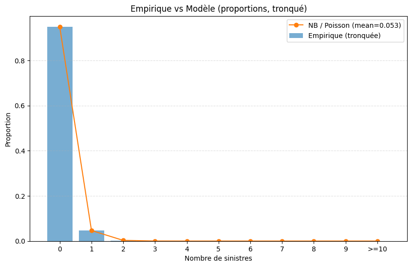

```python
# Comptages bruts (préservé)
counts = df_freq['ClaimNb'].value_counts().sort_index()

# 1) Troncature et agrégation de la queue
max_k = 10
counts_trunc = counts.reindex(range(0, max_k), fill_value=0)
tail = counts[counts.index >= max_k].sum()
counts_trunc[max_k] = tail
labels = list(range(0, max_k)) + [f">={max_k}"]
x = np.arange(len(labels))

# estimateur de la moyenne et de la variance (population)
mu = df_freq['ClaimNb'].mean()
var = df_freq['ClaimNb'].var(ddof=0)

# estimer paramètre r (shape) et p pour scipy.stats.nbinom
if var <= mu + 1e-8:
    warnings.warn("Variance ≤ moyenne -> pas de surdispersion détectée. Repli sur Poisson.")
    pmf = poisson.pmf(np.arange(0, max_k), mu)
    p_tail = 1 - poisson.cdf(max_k - 1, mu)
    pmf_with_tail = np.append(pmf, p_tail)
    print(f"Poisson utilisé: mean={mu:.4f}")
else:
    r = mu**2 / (var - mu)          # taille (shape)
    p = r / (r + mu)               # probabilité de "succès"
    # scipy nbinom parameterisation: n=r, p=p  -> pmf(k) = comb(k+n-1,k) * p^n * (1-p)^k
    pmf = nbinom.pmf(np.arange(0, max_k), r, p)
    p_tail = 1 - nbinom.cdf(max_k - 1, r, p)
    pmf_with_tail = np.append(pmf, p_tail)
    print(f"NB params estimés: r={r:.4f}, p={p:.4f}, mean≈{mu:.4f}, var≈{var:.4f}")

# proportions observées
obs_prop = counts_trunc.values / counts_trunc.values.sum()

# plot
plt.figure(figsize=(10,6))
plt.bar(x, obs_prop, color='C0', alpha=0.6, label='Empirique (tronquée)')
plt.plot(x, pmf_with_tail, 'o-', color='C1', label=f'NB / Poisson (mean={mu:.3f})')
plt.xticks(x, labels)
plt.title('Empirique vs Modèle (proportions, tronqué)')
plt.xlabel('Nombre de sinistres')
plt.ylabel('Proportion')
plt.legend()
plt.grid(axis='y', linestyle='--', alpha=0.4)
plt.show()
```

```python
#Faire un GLM comme précédement avec une loi binomiale négative

dfm = df_freq.loc[df_freq["Exposure"] > 0].copy()
# Formule : caté en C(), numériques en continu (splines conseillées)
formula = (
    "ClaimNb ~ "
    "C(VehBrand) + C(VehGas) + C(Area) + C(Region) + "
    "bs(DrivAge, df=5) + bs(VehAge, df=5) + "
    "BonusMalus + VehPower + Density"
)
modelBinomNeg = smf.glm(
    formula=formula,
    data=dfm,
    family=sm.families.NegativeBinomial(alpha=1.0),  # alpha à ajuster
    exposure=dfm["Exposure"],
)
resBinomNeg = modelBinomNeg.fit()       # robuste
print(resBinomNeg.summary())
```

```
                 Generalized Linear Model Regression Results
==============================================================================
Dep. Variable:                ClaimNb   No. Observations:               678013
Model:                            GLM   Df Residuals:                   677963
Model Family:        NegativeBinomial   Df Model:                           49
Link Function:                    Log   Scale:                          1.0000
Method:                          IRLS   Log-Likelihood:            -1.4094e+05
Date:                Fri, 26 Dec 2025   Deviance:                   1.8539e+05
Time:                        20:51:43   Pearson chi2:                 1.53e+06
No. Iterations:                     9   Pseudo R-squ. (CS):            0.01562
Covariance Type:            nonrobust
============================================================================================================
                                               coef    std err          z      P>|z|      [0.025      0.975]
------------------------------------------------------------------------------------------------------------
Intercept                                   -2.3997      0.113    -21.296      0.000      -2.621      -2.179
C(VehBrand)[T.B10]                          -0.0062      0.038     -0.162      0.871      -0.081       0.069
C(VehBrand)[T.B11]                           0.0639      0.041      1.552      0.121      -0.017       0.145
C(VehBrand)[T.B12]                           0.1155      0.019      6.148      0.000       0.079       0.152
C(VehBrand)[T.B13]                           0.0239      0.043      0.562      0.574      -0.060       0.107
C(VehBrand)[T.B14]                          -0.1858      0.081     -2.297      0.022      -0.344      -0.027
C(VehBrand)[T.B2]                           -0.0142      0.016     -0.898      0.369      -0.045       0.017
C(VehBrand)[T.B3]                            0.0062      0.023      0.273      0.785      -0.038       0.051
C(VehBrand)[T.B4]                           -0.0302      0.031     -0.980      0.327      -0.091       0.030
C(VehBrand)[T.B5]                            0.0668      0.026      2.591      0.010       0.016       0.117
C(VehBrand)[T.B6]                           -0.0454      0.029     -1.543      0.123      -0.103       0.012
C(VehGas)[T.Regular]                         0.0637      0.011      5.577      0.000       0.041       0.086
C(Area)[T.B]                                 0.0554      0.022      2.462      0.014       0.011       0.099
C(Area)[T.C]                                 0.0855      0.019      4.579      0.000       0.049       0.122
C(Area)[T.D]                                 0.1845      0.020      9.201      0.000       0.145       0.224
C(Area)[T.E]                                 0.2333      0.027      8.788      0.000       0.181       0.285
C(Area)[T.F]                                 0.2721      0.093      2.939      0.003       0.091       0.454
C(Region)[T.Aquitaine]                      -0.0568      0.095     -0.597      0.551      -0.243       0.130
C(Region)[T.Auvergne]                       -0.2784      0.118     -2.363      0.018      -0.509      -0.048
C(Region)[T.Basse-Normandie]                 0.0375      0.100      0.375      0.707      -0.158       0.233
C(Region)[T.Bourgogne]                       0.0213      0.102      0.209      0.835      -0.179       0.221
C(Region)[T.Bretagne]                        0.1194      0.093      1.280      0.200      -0.063       0.302
C(Region)[T.Centre]                          0.1020      0.092      1.110      0.267      -0.078       0.282
C(Region)[T.Champagne-Ardenne]               0.1646      0.123      1.343      0.179      -0.076       0.405
C(Region)[T.Corse]                           0.1542      0.113      1.367      0.172      -0.067       0.375
C(Region)[T.Franche-Comte]                  -0.0702      0.164     -0.427      0.670      -0.393       0.252
```

[output cut: 10 more lines]

```
C(Region)[T.Rhone-Alpes]                     0.1095      0.092      1.189      0.234      -0.071       0.290
bs(DrivAge, df=5)[0]                        -1.2320      0.077    -15.979      0.000      -1.383      -1.081
bs(DrivAge, df=5)[1]                        -0.3633      0.047     -7.701      0.000      -0.456      -0.271
bs(DrivAge, df=5)[2]                        -0.2499      0.073     -3.404      0.001      -0.394      -0.106
bs(DrivAge, df=5)[3]                        -0.7124      0.093     -7.624      0.000      -0.895      -0.529
bs(DrivAge, df=5)[4]                         0.5418      0.184      2.938      0.003       0.180       0.903
bs(VehAge, df=5)[0]                         -1.6760      0.029    -57.548      0.000      -1.733      -1.619
bs(VehAge, df=5)[1]                         -0.8967      0.024    -37.127      0.000      -0.944      -0.849
bs(VehAge, df=5)[2]                         -2.6797      0.130    -20.637      0.000      -2.934      -2.425
bs(VehAge, df=5)[3]                         -2.4942      0.798     -3.125      0.002      -4.058      -0.930
bs(VehAge, df=5)[4]                         -1.8697      0.834     -2.241      0.025      -3.505      -0.234
BonusMalus                                   0.0233      0.000     64.417      0.000       0.023       0.024
VehPower                                     0.0090      0.003      3.137      0.002       0.003       0.015
Density                                  -2.349e-06   3.84e-06     -0.612      0.540   -9.87e-06    5.17e-06
============================================================================================================
```

# Adéquation du modèle

## Déviance :

Ecart entre la log-vraissemblance modèle saturé et modèle ajusté (la plus basse possible)

## Test de Wald (Z) :

Significativité des variables Compare à l'hypothèse H0:"La valeur de l'estimateur de lavariable est 0" On veut rejeter le test (si $\alpha = 5%$ la P-value doit etre inférieur à 0,05 ou 0 dans l'IC)

# Robustesse du modèle

## Résidus de Pearson standardisé :

Verification visuelle : pseudo-linéarité (résidus doivent être répartis de manière aléatoire autour de 0), hétérosédasticité (bande quasi-horizontale autour de 0 sans effet entonnoir)

# Performance du modèle

## Courbe de Lorenz:

```python
#calculer la déviance du modèle saturé et comparer à la déviance de mon modèle binomial négatif
# Déviance : Ecart entre la log-vraissemblance modèle saturé et modèle ajusté (la plus basse possible)
deviance_saturated = 0  # par définition
deviance_model = resBinomNeg.deviance
print(f"Déviance du modèle binomial négatif: {deviance_model:.4f}")
```

```
Déviance du modèle binomial négatif: 185385.1872
```

```python
#Donner la liste et le nombre des variables significatives au seuil 5%
significant_vars = resBinomNeg.pvalues[resBinomNeg.pvalues < 0.05].index.tolist()
print("Variables significatives au seuil 5% :", significant_vars)
print("Nombre de variables significatives au seuil 5% :", len(significant_vars))
```

```
Variables significatives au seuil 5% : ['Intercept', 'C(VehBrand)[T.B12]', 'C(VehBrand)[T.B14]', 'C(VehBrand)[T.B5]', 'C(VehGas)[T.Regular]', 'C(Area)[T.B]', 'C(Area)[T.C]', 'C(Area)[T.D]', 'C(Area)[T.E]', 'C(Area)[T.F]', 'C(Region)[T.Auvergne]', 'bs(DrivAge, df=5)[0]', 'bs(DrivAge, df=5)[1]', 'bs(D…
Nombre de variables significatives au seuil 5% : 23
```

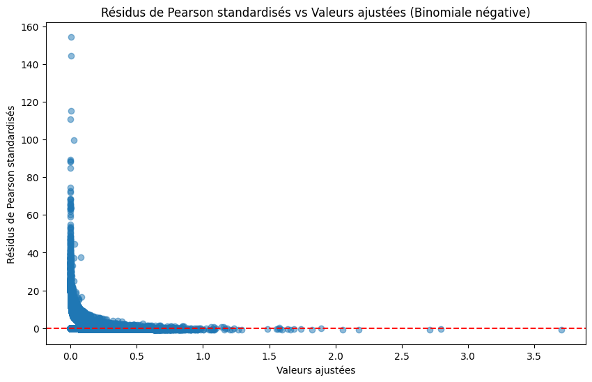

```python
#Graphe des Résidus de Pearson standardisé sur la binomiale négative

pearson_resid = resBinomNeg.resid_pearson
fitted_vals = resBinomNeg.fittedvalues
plt.figure(figsize=(10,6))
plt.scatter(fitted_vals, pearson_resid, alpha=0.5)
plt.axhline(0, color='red', linestyle='--')
plt.title('Résidus de Pearson standardisés vs Valeurs ajustées (Binomiale négative)')
plt.xlabel('Valeurs ajustées')
plt.ylabel('Résidus de Pearson standardisés')
plt.show()
```

Le graphique des résidus de Pearson standardisés présente énormément d'effectifs à zéro une majorité de points concentrée autour de zéro, indiquant une bonne adéquation globale du modèle. Quelques valeurs extrêmes apparaissent pour des observations à faible fréquence ajustée, phénomène attendu dans les modèles de fréquence automobile en raison de la rareté des sinistres (forte proportion de zéros). Ces résidus élevés ne traduisent pas un défaut de spécification, mais la nature discrète et surdispersée des données.

Pour une distribution de nombre de sinistre X par exemple, la courbe de Lorenz est tracée en associant à chaque nombre de sinistre x un point dont les coordonnées sont F(x) en abscisse et G(x) en ordonnée. ◦ F(x) représente la proportion des individus ayant moins de x sinistres. ◦ G(x) représente la proportion de la masse totale M des sinistres correspondant à ces individus (Masse des sinistres <x / Masse totale M)

Cette courbe est toujours située en dessous de la première bissectrice, car F(x)>G(x)

Nous pondérons les F(x) par l'exposure

La courbe de Lorenz permet d’apprécier la concentration du risque au sein d’un portefeuille.  
Pour une variable de comptage $X$ représentant le nombre de sinistres, elle associe à chaque proportion cumulée d’exposition $F(x)$ la proportion cumulée de sinistres observés $G(x)$ :

$F(x) = \frac{\sum_{i: X_i \le x} \text{Exposure}_i}{\sum_i \text{Exposure}_i}, \qquad G(x) = \frac{\sum_{i: X_i \le x} X_i}{\sum_i X_i}.$

La courbe de Lorenz est toujours située en dessous de la première bissectrice, c’est-à-dire : $F(x) \ge G(x), \quad \forall x $ ce qui traduit le fait qu’une minorité d’assurés concentre la majorité des sinistres.

Dans le cadre d’un modèle de fréquence, la courbe est tracée après tri des contrats par risque prédictif croissant $\hat{\mu}_i$.  
Elle permet ainsi de mesurer la capacité discriminante du modèle :  
un écart marqué à la diagonale indique une bonne différenciation des risques, tandis qu’une courbe proche de la bissectrice traduit un faible pouvoir de discrimination.

```
Fréquence moyenne observée : 0.100703
Fréquence moyenne prédite  : 0.102357
Indice de Gini pondéré (fréquence) : 0.281
```

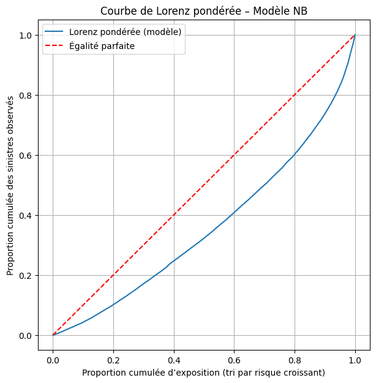

```
Table par déciles (tri croissant du risque) :
        exposition  sinistres  freq_obs  freq_pred  lift_obs  lift_pred
decile
1       41211.1675     1826.0    0.0443     0.0513    0.4400     0.5095
2       40731.4545     2517.0    0.0618     0.0631    0.6136     0.6264
3       40274.6707     2886.0    0.0717     0.0702    0.7116     0.6974
4       39724.7084     3088.0    0.0777     0.0767    0.7719     0.7613
5       39404.6934     3196.0    0.0811     0.0829    0.8054     0.8237
6       38523.2454     3485.0    0.0905     0.0898    0.8983     0.8920
7       36366.2207     3601.0    0.0990     0.0988    0.9833     0.9816
8       32542.1021     3939.0    0.1210     0.1164    1.2020     1.1555
9       28224.1075     4643.0    0.1645     0.1724    1.6336     1.7119
10      21497.0753     6921.0    0.3220     0.3331    3.1970     3.3078
```

```python
# ==== Courbe de Lorenz pondérée & Indice de Gini (fréquence) ====
# Prérequis : 'resBinomNeg' = résultat d'un GLM statsmodels avec exposure (NB/Poisson)
# - Abscisse : exposition cumulée (pondération)
# - Ordonnée : sinistres observés cumulés (comptes, sans repondération)
# - Tri : par taux prédit (comptes prédits / exposition)
# - Gini (tri croissant) : G = 1 - 2 * AUC



def lorenz_gini_deciles(res_glm, y_col="ClaimNb", w_col="Exposure", plot_title=None):
    # 1) Récupération alignée (mêmes lignes, même ordre que le fit)
    df_fit = res_glm.model.data.frame.copy()
    y  = df_fit[y_col].astype(float).to_numpy()
    w  = df_fit[w_col].astype(float).to_numpy()
    mu_counts = np.asarray(res_glm.fittedvalues, dtype=float)  # E[y] = comptes attendus

    # Nettoyage
    m = np.isfinite(y) & np.isfinite(w) & np.isfinite(mu_counts) & (w > 0)
    y, w, mu_counts = y[m], w[m], mu_counts[m]

    # 2) Sanity check (fréquences moyennes)
    freq_obs  = y.sum() / w.sum()
    freq_pred = mu_counts.sum() / w.sum()
    print(f"Fréquence moyenne observée : {freq_obs:.6f}")
    print(f"Fréquence moyenne prédite  : {freq_pred:.6f}")

    # 3) Construction Lorenz : trier par TAUX prédit = comptes / exposition
    mu_rate = mu_counts / w
    order = np.argsort(mu_rate)               # tri croissant du risque
    y, w, mu_rate = y[order], w[order], mu_rate[order]

    # Abscisse (exposition cumulée) & Ordonnée (sinistres cumulés)
    x = np.cumsum(w) / w.sum()
    Y = np.cumsum(y) / y.sum()
    # Forcer (0,0) et (1,1)
    x = np.concatenate(([0.0], x, [1.0]))
    Y = np.concatenate(([0.0], Y, [1.0]))

    # 4) Indice de Gini (tri croissant -> courbe sous la diagonale)
    auc  = np.trapezoid(Y, x)                 # numpy >= 2.0
    gini = abs(1.0 - 2.0 * auc)
    print(f"Indice de Gini pondéré (fréquence) : {gini:.3f}")

    # 5) Tracé
    plt.figure(figsize=(7,7))
    plt.plot(x, Y, label="Lorenz pondérée (modèle)")
    plt.plot([0,1], [0,1], "r--", label="Égalité parfaite")
    plt.xlabel("Proportion cumulée d’exposition (tri par risque croissant)")
    plt.ylabel("Proportion cumulée des sinistres observés")
    plt.title(plot_title or "Courbe de Lorenz pondérée – Modèle de fréquence")
    plt.legend(); plt.grid(True); plt.show()

    # 6) Table par déciles (discrimination + calibration simple)
    df_rank = pd.DataFrame({"y": y, "w": w, "mu_rate": mu_rate})
    df_rank["decile"] = pd.qcut(df_rank["mu_rate"], 10, labels=False, duplicates="drop") + 1
    tab = df_rank.groupby("decile").apply(
        lambda g: pd.Series({
            "exposition": g["w"].sum(),
            "sinistres":  g["y"].sum(),
            "freq_obs":   g["y"].sum() / g["w"].sum(),
            "freq_pred":  np.average(g["mu_rate"], weights=g["w"])
        })
    )
    f_mean = freq_obs
    tab["lift_obs"]  = tab["freq_obs"]  / f_mean
    tab["lift_pred"] = tab["freq_pred"] / f_mean
    print("\nTable par déciles (tri croissant du risque) :")
    print(tab.round(4))

    return {"gini": gini, "x": x, "Y": Y, "deciles": tab}

résultats = lorenz_gini_deciles(resBinomNeg, y_col="ClaimNb", w_col="Exposure",
                                plot_title="Courbe de Lorenz pondérée – Modèle NB")
```

Le modèle de fréquence ajusté sous loi binomiale négative présente une bonne adéquation globale : la fréquence moyenne prédite (0.102) est très proche de la fréquence observée (0.101), ce qui traduit une calibration correcte du modèle. La courbe de Lorenz montre une courbure marquée, traduisant une différenciation effective des risques. L’indice de Gini pondéré, égal à 0.281, indique un pouvoir discriminant satisfaisant.

Nous faisons maintenant par validation croisé l'indice de GINI et la courbe de Lorenz pour vérifier qu'il n'y a pas d'overfitting

```
[CV] Fold 1/5 : Gini OOF = 0.271
[CV] Fold 2/5 : Gini OOF = 0.268
[CV] Fold 3/5 : Gini OOF = 0.281
[CV] Fold 4/5 : Gini OOF = 0.282
[CV] Fold 5/5 : Gini OOF = 0.292

[CV] Gini OOF moyen (± écart-type) : 0.279 ± 0.010
[CV] Gini OOF global (OOF recollé) : 0.279
```

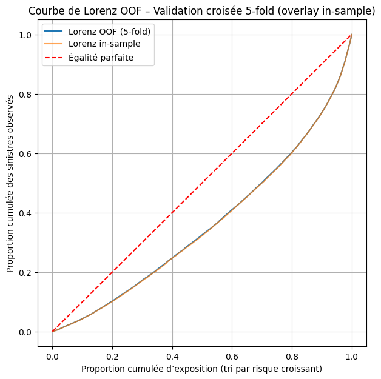

```python
# ===== Validation croisée k-fold : courbes de Lorenz OOF + Gini =====


from sklearn.model_selection import KFold

def kfold_lorenz_oof(res_glm, y_col="ClaimNb", w_col="Exposure",
                     k=5, shuffle=True, random_state=42, plot=True, overlay_insample=False):
    """
    Refit le GLM (même formula & family) sur k-1 folds et prédit sur le fold restant (OOF).
    Calcule et trace la courbe de Lorenz OOF + Gini par fold et global.
    """
    # Récupère la data & les méta du modèle existant (sans rien recoder)
    df_all  = res_glm.model.data.frame.copy()
    formula = getattr(res_glm.model, "formula", None)
    family  = res_glm.family
    if formula is None:
        raise ValueError("Le modèle original doit avoir été ajusté via une formule (smf.glm).")

    # Structures OOF
    oof_counts = pd.Series(index=df_all.index, dtype=float)

    # KFold scikit-learn
    kf = KFold(n_splits=k, shuffle=shuffle, random_state=random_state)
    gini_folds = []

    for i, (tr_idx, va_idx) in enumerate(kf.split(df_all), start=1):
        df_tr = df_all.iloc[tr_idx]
        df_va = df_all.iloc[va_idx]

        # Refit GLM (fonction existante)
        model = smf.glm(formula=formula, data=df_tr, family=family, exposure=df_tr[w_col])
        res_fold = model.fit()

        # Prédictions COMPTES sur le fold de validation
        mu_va_counts = res_fold.predict(df_va, exposure=df_va[w_col])
        oof_counts.iloc[va_idx] = mu_va_counts.to_numpy(float)

        # Lorenz & Gini du fold (utilise pandas/numpy)
        df_va_rank = df_va.assign(mu_rate = mu_va_counts / df_va[w_col]).sort_values("mu_rate")
        xv = df_va_rank[w_col].cumsum() / df_va_rank[w_col].sum()
        yv = df_va_rank[y_col].cumsum() / df_va_rank[y_col].sum()
        xv = pd.concat([pd.Series([0.0]), xv, pd.Series([1.0])]).to_numpy()
        yv = pd.concat([pd.Series([0.0]), yv, pd.Series([1.0])]).to_numpy()
        try:
            auc_v = np.trapezoid(yv, xv)
        except AttributeError:
            auc_v = np.trapz(yv, xv)
        gini_v = abs(1.0 - 2.0*auc_v)
        gini_folds.append(gini_v)
        print(f"[CV] Fold {i}/{k} : Gini OOF = {gini_v:.3f}")

    # Courbe & Gini OOF "global"
    df_oof = df_all.assign(mu_rate = oof_counts / df_all[w_col]).sort_values("mu_rate")
    xo = df_oof[w_col].cumsum() / df_oof[w_col].sum()
    yo = df_oof[y_col].cumsum() / df_oof[y_col].sum()
    xo = pd.concat([pd.Series([0.0]), xo, pd.Series([1.0])]).to_numpy()
    yo = pd.concat([pd.Series([0.0]), yo, pd.Series([1.0])]).to_numpy()
    try:
        auc_o = np.trapezoid(yo, xo)
    except AttributeError:
        auc_o = np.trapz(yo, xo)
    gini_oof = abs(1.0 - 2.0*auc_o)

    print(f"\n[CV] Gini OOF moyen (± écart-type) : {np.mean(gini_folds):.3f} ± {np.std(gini_folds, ddof=1):.3f}")
    print(f"[CV] Gini OOF global (OOF recollé) : {gini_oof:.3f}")

    # Tracé OOF
    if plot:
        plt.figure(figsize=(7,7))
        plt.plot(xo, yo, label=f"Lorenz OOF ({k}-fold)")
        if overlay_insample and 'résultats' in globals():
            plt.plot(résultats["x"], résultats["Y"], label="Lorenz in-sample", alpha=0.7)
        plt.plot([0,1], [0,1], "r--", label="Égalité parfaite")
        plt.xlabel("Proportion cumulée d’exposition (tri par risque croissant)")
        plt.ylabel("Proportion cumulée des sinistres observés")
        ttl = f"Courbe de Lorenz OOF – Validation croisée {k}-fold"
        if overlay_insample: ttl += " (overlay in-sample)"
        plt.title(ttl)
        plt.legend(); plt.grid(True); plt.show()

    return {
        "gini_folds": gini_folds,
        "gini_oof": gini_oof,
        "x_oof": xo,
        "y_oof": yo,
        "oof_counts": oof_counts
    }

# ===== Lancement de la validation croisée (OOF) =====
cv = kfold_lorenz_oof(
    resBinomNeg,
    y_col="ClaimNb",
    w_col="Exposure",
    k=5, shuffle=True, random_state=42,
    plot=True,
    overlay_insample=True   # met à True si 'résultats' (in-sample) existe pour comparer visuellement
)
```

La validation croisée 5-fold donne un indice de Gini moyen de 0.279 (+/- 0.010), très proche du Gini in-sample (0.281). Cela indique une bonne capacité de généralisation du modèle binomial négatif, sans signe d’overfitting. La superposition des courbes de Lorenz in-sample et OOF (en validation croisée) confirme visuellement la stabilité du modèle.

Toutes les variables disponibles ont été conservées, la validation croisée n’indiquant pas de sur-apprentissage.

```python
# 1) Coefficients (table propre)
coefs = pd.DataFrame({
    "param": resBinomNeg.params.index,
    "beta":  resBinomNeg.params.values
})
print(coefs)

# 2) Fréquence prédite (taux par unité d'exposition) et nombre attendu
df_fit = resBinomNeg.model.data.frame.copy()
w = df_fit["Exposure"].astype(float).to_numpy()
mu_counts = np.asarray(resBinomNeg.fittedvalues, dtype=float)  # E[Y] (comptes)
lambda_rate = mu_counts / w                                    # fréquence (taux)

print("Fréquence moyenne prédite :", lambda_rate.mean())
print("Comptes moyens prédits   :", mu_counts.mean())
```

```
                  param      beta
0             Intercept -2.399662
1    C(VehBrand)[T.B10] -0.006186
2    C(VehBrand)[T.B11]  0.063945
3    C(VehBrand)[T.B12]  0.115481
4    C(VehBrand)[T.B13]  0.023909
..                  ...       ...
45  bs(VehAge, df=5)[3] -2.494199
46  bs(VehAge, df=5)[4] -1.869707
47           BonusMalus  0.023295
48             VehPower  0.008991
49              Density -0.000002

[50 rows x 2 columns]
Fréquence moyenne prédite : 0.11624746693885092
Comptes moyens prédits   : 0.054121443164726196
```

## MODELE SEVERITE - LOI GAMMA

```python
df_sev.head()
df_sev.info()
df_sev
#Créer un dataset 'df_cout' qui joint df_freq et df_sev sur IDpol puis supprimer ClaimNb et IDpol
df_cout = pd.merge(df_freq, df_sev, on="IDpol", how="inner")
df_cout = df_cout.drop(columns=["ClaimNb", "IDpol"])
df_cout
#Vérifier on devrait avoir  11 colonnes
print(df_cout.shape)  # (, 11) On a moins de de lignes à cause des individus avec ClaimNb=0
display(df_cout)
df_cout.info()
```

```
<class 'pandas.core.frame.DataFrame'>
RangeIndex: 26639 entries, 0 to 26638
Data columns (total 2 columns):
 #   Column       Non-Null Count  Dtype
---  ------       --------------  -----
 0   IDpol        26639 non-null  int64
 1   ClaimAmount  26639 non-null  float64
dtypes: float64(1), int64(1)
memory usage: 416.4 KB
(26444, 11)
```

|  | Exposure | VehPower | VehAge | DrivAge | BonusMalus | VehBrand | VehGas | Area | Density | Region | ClaimAmount |
| --- | --- | --- | --- | --- | --- | --- | --- | --- | --- | --- | --- |
| 0 | 0.75 | 7 | 1 | 61 | 50 | B12 | Regular | F | 27000 | Ile-de-France | 303.00 |
| 1 | 0.14 | 12 | 5 | 50 | 60 | B12 | Diesel | B | 56 | Basse-Normandie | 1981.84 |
| 2 | 0.14 | 4 | 0 | 36 | 85 | B12 | Regular | E | 4792 | Ile-de-France | 1456.55 |
| 3 | 0.62 | 10 | 0 | 51 | 100 | B12 | Regular | F | 27000 | Ile-de-France | 989.64 |
| 4 | 0.62 | 10 | 0 | 51 | 100 | B12 | Regular | F | 27000 | Ile-de-France | 9844.36 |
| ... | ... | ... | ... | ... | ... | ... | ... | ... | ... | ... | ... |
| 26439 | 0.14 | 7 | 2 | 51 | 50 | B12 | Diesel | C | 178 | Aquitaine | 1769.88 |
| 26440 | 0.17 | 4 | 0 | 35 | 51 | B12 | Regular | D | 1719 | Rhone-Alpes | 1288.28 |
| 26441 | 0.17 | 15 | 3 | 36 | 50 | B12 | Regular | C | 181 | Poitou-Charentes | 1029.00 |
| 26442 | 0.17 | 15 | 3 | 36 | 50 | B12 | Regular | C | 181 | Poitou-Charentes | 1940.40 |
| 26443 | 0.13 | 7 | 10 | 39 | 50 | B4 | Regular | D | 820 | Nord-Pas-de-Calais | 1452.00 |

26444 rows × 11 columns

```
<class 'pandas.core.frame.DataFrame'>
RangeIndex: 26444 entries, 0 to 26443
Data columns (total 11 columns):
 #   Column       Non-Null Count  Dtype
---  ------       --------------  -----
 0   Exposure     26444 non-null  float64
 1   VehPower     26444 non-null  int64
 2   VehAge       26444 non-null  int64
 3   DrivAge      26444 non-null  int64
 4   BonusMalus   26444 non-null  int64
 5   VehBrand     26444 non-null  object
 6   VehGas       26444 non-null  object
 7   Area         26444 non-null  object
 8   Density      26444 non-null  int64
 9   Region       26444 non-null  object
 10  ClaimAmount  26444 non-null  float64
dtypes: float64(2), int64(5), object(4)
memory usage: 2.2+ MB
```

[figure not shown]

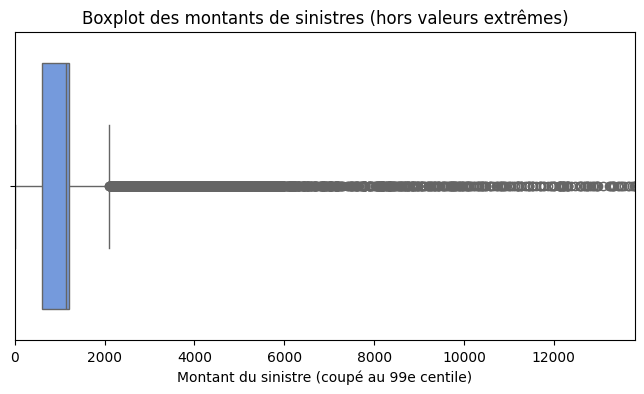

```
count      26444.00
mean        2077.53
std        29267.68
min            1.00
25%          602.00
50%         1128.12
75%         1204.00
max      4075400.56
Name: ClaimAmount, dtype: float64
```

```python
#distribution de la variable ClaimAmount


plt.figure(figsize=(10,6))
plt.hist(df_sev["ClaimAmount"], bins=100, color='steelblue', edgecolor='black', alpha=0.7)
plt.xscale("log")
plt.xlabel("Montant du sinistre (échelle logarithmique)")
plt.ylabel("Fréquence")
plt.title("Distribution logarithmique de ClaimAmount")
plt.grid(True, which="both", ls="--", alpha=0.5)
plt.show()



plt.figure(figsize=(8,4))
sns.boxplot(x=df_sev["ClaimAmount"], color='cornflowerblue')
plt.xlim(0, df_sev["ClaimAmount"].quantile(0.99))  # on coupe les 1% extrêmes
plt.xlabel("Montant du sinistre (coupé au 99e centile)")
plt.title("Boxplot des montants de sinistres (hors valeurs extrêmes)")
plt.show()


#Faire un résumé statistique de la variable ClaimAmount (avec les décimales)
print(df_cout['ClaimAmount'].describe().round(2))
```

### CHOIX DE LA DISTRIBUTION DE LA CIBLE ClaimAmount

La variable ClaimAmount présente une distribution extrêmement asymétrique à droite. La majorité des sinistres sont de faible montant , tandis qu’un petit nombre de cas atteignent plusieurs centaines de milliers, voire plusieurs millions d’euros. Cette forte hétérogénéité justifie l’utilisation d’une loi Gamma (ou log-normale) pour modéliser la sévérité, permettant de représenter la variance croissante avec la moyenne.

Les 2 lois sont utilisées pour modéliser les coûts des sinistres(variables continues et positives). La loi Gamma est adaptée aux branches présentant avec une grande majorité de sinistres peu coûteux et des sinistres graves rares. La loi log-normale, moins fréquemment utilisée, modélise des portefeuilles avec des sinistres graves plus importants (queue de distribution plus épaisse que la loi gamma).

Nous allons tester l'adéquation de la variable cible ClaimAmount à une loi gamma par un qq-plot (droite de Henry)

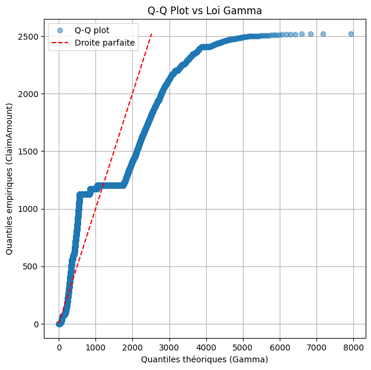

```python
#tester l'adéquation de la variable cible ClaimAmount à une loi gamma par un qq-plot (droite de Henry)
# et par un test d'adéquation du khi II (df_cout['ClaimAmount'])

#Données
data = df_cout['ClaimAmount'].dropna()
data = data[data > 0] #sécurité si 0
# Coupe au 90e centile
cutoff = np.percentile(data, 90)
data_trimmed = data[data <= cutoff]
#=======================
#  Q-Q Plot : Loi Gamma
# =======================
# Ajustement des paramètres Gamma (shape, loc=0, scale)
gamma_params = stats.gamma.fit(data_trimmed, floc=0)
shape, loc, scale = gamma_params
# Quantiles théoriques (n points uniformes → transformés par la quantile fonction Gamma)
n = len(data_trimmed)
probs = (np.arange(1, n+1) - 0.5) / n
theoretical_q_gamma = stats.gamma.ppf(probs, a=shape, loc=loc, scale=scale)
# Quantiles empiriques
empirical_q = np.sort(data_trimmed)
# Tracé
plt.figure(figsize=(7,7))
plt.plot(theoretical_q_gamma, empirical_q, 'o', alpha=0.5, label='Q-Q plot')
plt.plot([empirical_q.min(), empirical_q.max()], [empirical_q.min(), empirical_q.max()], 'r--', label='Droite parfaite')
plt.xlabel('Quantiles théoriques (Gamma)')
plt.ylabel('Quantiles empiriques (ClaimAmount)')
plt.title('Q-Q Plot vs Loi Gamma')
plt.legend();
plt.grid(True)
plt.show()
```

On va effectuer une première régression Gamma sur les données, sans sélection préalable de variables explicatives.

La fonction de lien choisie est la fonction logarithme. La fonction canonique est la fonction inverse, mais la fonction logarithme est préférée en non-vie car :

- Il garantit que les primes (ou les coûts moyens) prédites μ ne sont jamais négatives.
- Chaque facteur de risque a un effet proportionnel sur la prime totale Le prédicteur linéaire est noté $\eta = \beta'X$.

Le modèle est défini par : $E(Y \mid X) = \mu = \exp(\eta)$